## <sup>The Story Behind the Numbers: An In-Depth Look at Top Amazon Sales of Technology Products in 2019</sup>

This report provides an in-depth analysis of the top product sales of Amazon in 2019. It provides valuable insights into customer behavior and preferences, and identifies trends and patterns that can help Marketing and Sales team to understand which products were the most popular among Amazon customers. They can use this information to make informed decisions about which products to prioritize in their marketing and promotional campaigns.

### <sup>**GRAPH_1- Top 10 Best-Selling Products in 2019**</sup>

This graph shows total sales of top 10 product and the no. of orders placed at the each of each bar. Knowing which products are popular can help the Marketing and Sales team to manage inventory levels and ensure that they have enough stock to meet customer demand. It can also help them make decisions about which products to restock or discontinue based on their popularity.

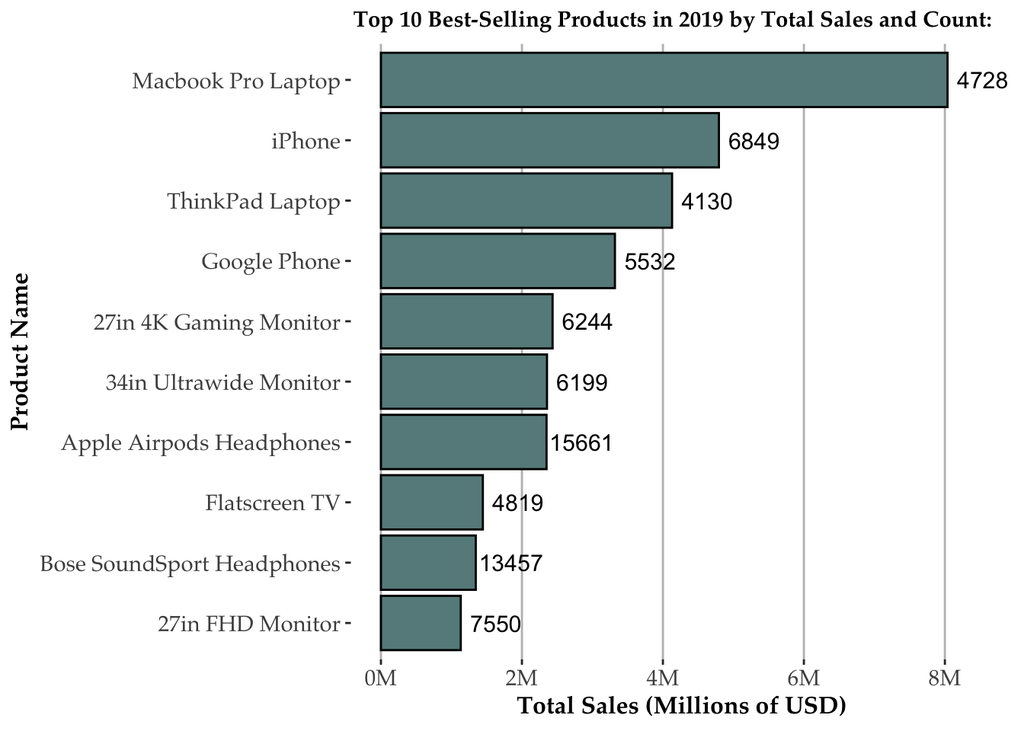

### <sup>**GRAPH_2: Monthly Sales Trends for Top 4 Selling Products in 2019**</sup>

The graph provides a month-by-month breakdown of the sales trends for the top 4 products, which can help the team to identify any seasonal trends, forecast sales and product trends.It can be seen that the peak sales months are Apr, Oct and December.

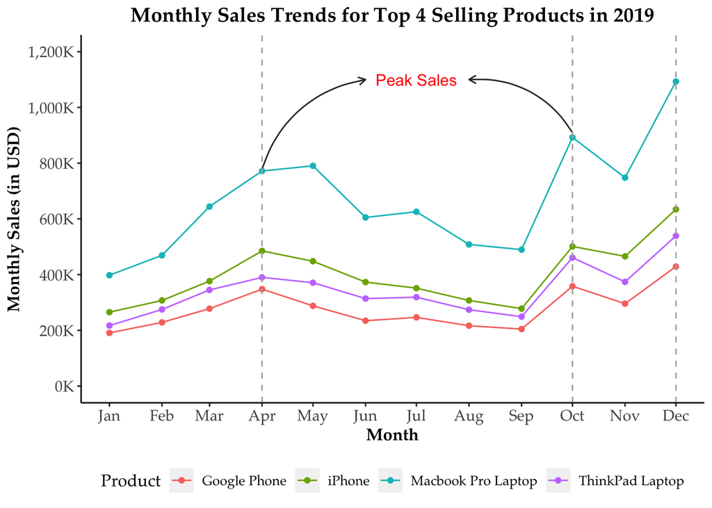

### <sup>**GRAPH_3: “Zip Code Breakdown of Top Selling Products”**</sup>

The graph can also be used to analyze the competition in each region. Although the trend of all the products is same the quantity differs. By understanding which products are popular in each zip code, the team can identify areas where there may be an opportunity to compete with other retailers or increase market share.

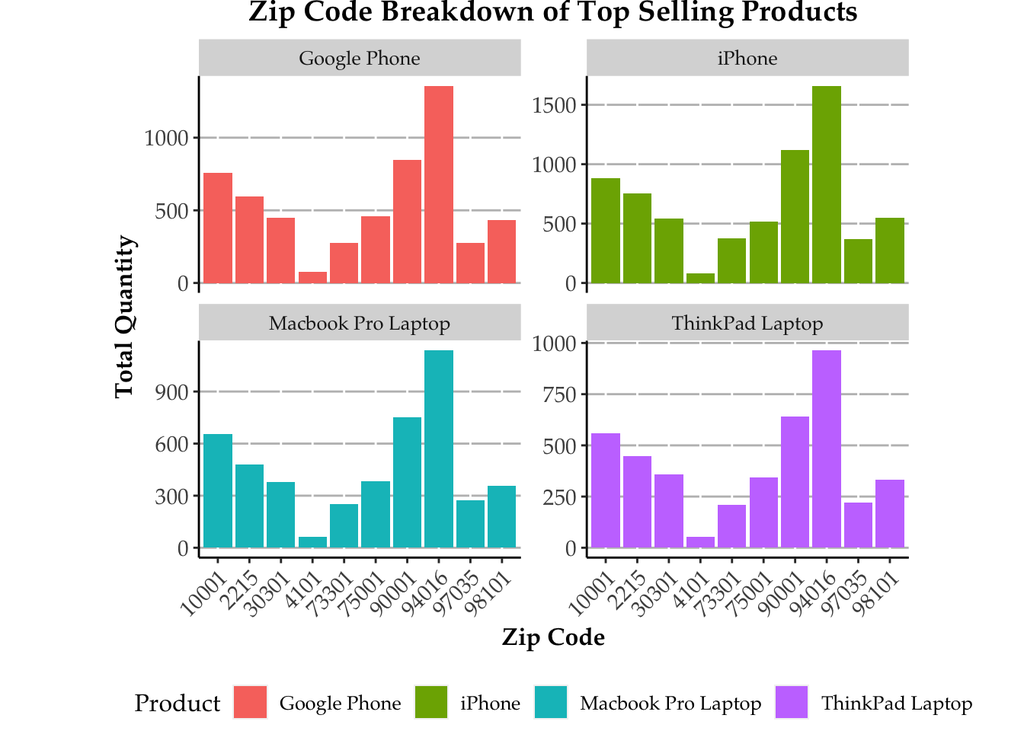

### <sup>**GRAPH_4- Total Sales of MacBook Pro Laptop by Hour and Day of Week**</sup>

By analyzing this graph, the marketing team can identify that MacBook Pro sales are highest between 11Am to 9PM, and use this information to target their marketing campaigns more effectively. For example, they may choose to run targeted ads during peak sales hours or days, or schedule promotions during times when sales are traditionally slower.

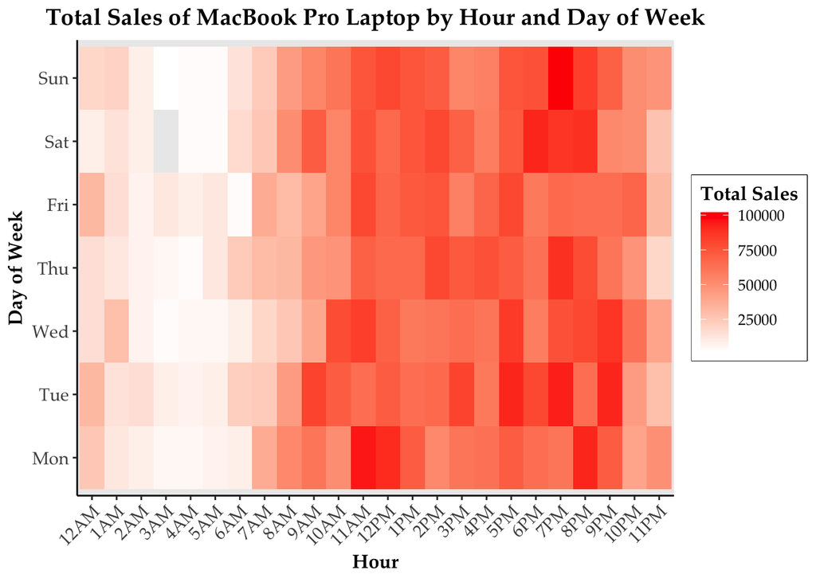

### <sup>**GRAPH_5: Percentage of Population in Each Zip Code That Purchased IPhones**</sup>

The Sales team can use this data to segment customers by zip code and develop personalized sales strategies. For example, they could offer promotions and discounts in zip codes with lower percentages to encourage more purchases and increase the percentage of population that buys Iphone.

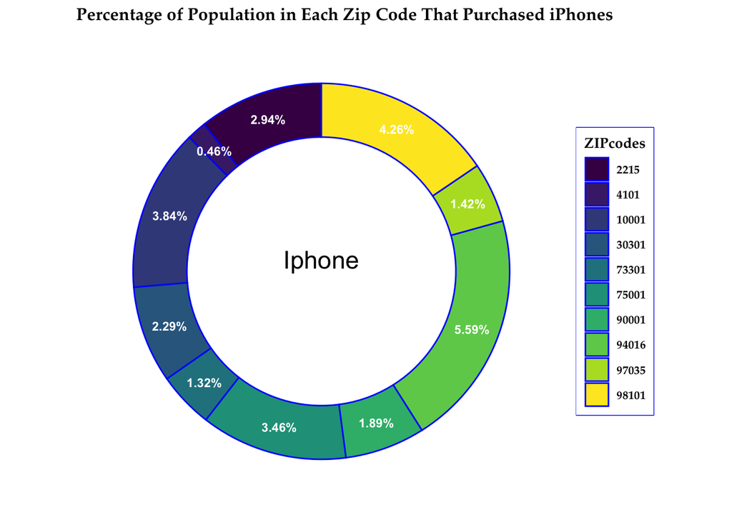

Overall, this report provides a valuable resource for anyone interested in the technology market, including investors, marketing teams, and business leaders. It presents a detailed analysis of the top product sales on Amazon, and provides insights and recommendations that can inform decision-making and drive growth and profitability.